# ManyBabies Habituation Project

This project aims to explore infant habituation through looking times using a large harmonised dataset from ManyBabies 1, ManyBabies 3, and ManyBabies 4. Study-relevant materials can be found on the Open Science Framework: https://osf.io/8xm4r

Authors

Affiliations

Suzanne Aussems

Department of Psychology, University of Warwick

Piyali Bhattacharya

School of Psychology, University of Birmingham

Jasmin Dönicke

University Medical Center Mainz

Naomi Havron

Department of Psychology, University of Haifa

Mahmoud Elsherif

School of Psychology, University of Birmingham

Catia Ferreira De Oliveira

Cardiff University

Published

May 31, 2026

# 1 RQ1 - Shape of habituation curve

Explore which functional forms best capture habituation trajectories.

## 1.1 Prepare Data

```r
# libraries
library(dplyr)
library(ggplot2)
library(lme4)
library(splines)
library(broom.mixed)
library(tidyr)
library(purrr)
library(stringr)
library(mgcv)
library(gratia)
library(Matrix) # package for lme4
library(pbkrtest) # package for parametric bootstrapping test
library(lme4) #package for performing linear mixed models
library(languageR) #package for tidyverse
library(car) #Provide variance inflation factor and package to extract p values
library(MuMIn) # report marginal and condition R2 values for variance explained
library(tidyverse) # to make tidy data, access pipes and make graphs
library(ggpubr) #To make graphs on multiple panels
library(reshape2)#package for tidyverse
library(rlang) # package for tidyverse
library(simr) #package to assess power
library(broom.mixed) #provide tidy model outputs
library(afex) #for p-values
library(viridis)#for colourblind friendly images
library(splines)
library(dplyr)
library(tidyr)
library(ggplot2)
library(ggeffects)
library(lme4)
library(lmerTest)
library(emmeans)
library(splines)
library(performance) # For R-squared and model checks
library(sjPlot)      # For standardized coefficient tables
library(patchwork)   # For multi-panel distribution plots

# set environment

# read CSV
data <- read.csv("final_merged_manybabies.csv")

# assign factors
data <- data %>%
  mutate(across(where(is.character), as.factor))

# harmonize two age-variables into one
unique(data$age_group_new)
max(data$age_days)

data <- data %>%
  dplyr::mutate(
    age = cut(
      age_days,
      breaks = c(0, 90, 180, 270, 365, 455, 545, 635, 653),  # boundaries in days
      labels = c(
        "< 3 months",
        "3–6 months",
        "6–9 months",
        "9–12 months",
        "12–15 months",
        "15–18 months",
        "18–21 months",
        "21 + months"
      ),
      right = FALSE
    )
  )

data <- data %>%
  dplyr::mutate(
    age = dplyr::coalesce(age_group_new, age)
  )

data <- data %>%
  dplyr::mutate(
    age = factor(age, levels = c(
      "< 3 months",
      "3–6 months",
      "6–9 months",
      "9–12 months",
      "12–15 months",
      "15–18 months",
      "18–21 months",
      "21 + months"
    ))
  )

# create variable with only testing trials (Training trials [-2, -1, 0] are excluded because they serve familiarization purposes and are not relevant for the main outcome)
data <- data %>%
  dplyr::mutate(
    testing_trial = ifelse(trial_number > 0, trial_number, NA)
  )

# log-transform data (The log transformation is useful because looking times are usually skewed, and scaling helps especially when fitting random slopes and GAMs.)
data <- data %>%
  mutate(
    unique_subject_identifier = as.factor(unique_subject_identifier),
    lab_id = as.factor(lab_id),
    project_id = as.factor(project_id),
    log_looking_time = log1p(looking_time),
    testing_trial_sc = as.numeric(scale(testing_trial)),
    age_days_sc = as.numeric(scale(age_days))
  )

# remove NA for complete-case analysis
data_model <- data %>%
  filter(!is.na(looking_time))

# clean modelling data => final clean-up
data_model <- data %>%
  filter(
    !is.na(looking_time),
    !is.na(testing_trial),
    !is.na(unique_subject_identifier),
    !is.na(project_id),
    !is.na(lab_id)
  ) %>%
  mutate(
    log_looking_time = log1p(looking_time),
    testing_trial_sc = as.numeric(scale(testing_trial))
  )
```

## 1.2 Simplify Data

We have roughly 55,000 observations. When testing new code, I can use this smaller sample so things run faster (= use data_sample). Once your code is ready, I will apply it to the full dataset (= use data).

```r
set.seed(123)

data_sample <- data %>%
  dplyr::sample_n(5000)
```

## 1.3 Plot Overall Habituation Curve

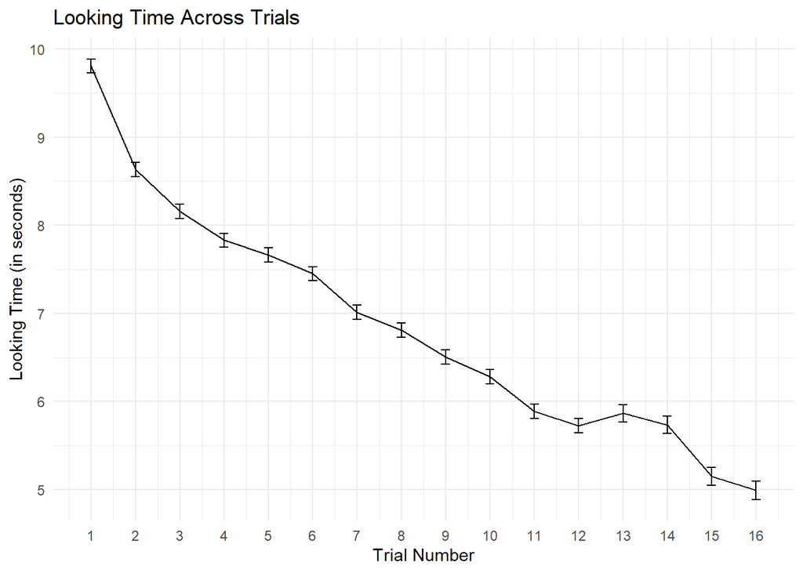

```r
ggplot(data, aes(x = testing_trial, y = looking_time)) +
  stat_summary(fun = mean, geom = "line") +
  stat_summary(fun.data = mean_se, geom = "errorbar", width = 0.2) +
  scale_x_continuous(
    breaks = seq(1, max(data$testing_trial, na.rm = TRUE), by = 1)
  ) +
  labs(
    x = "Trial Number",
    y = "Looking Time (in seconds)",
    title = "Looking Time Across Trials"
  ) +
  theme_minimal()
```

## 1.4 Create Overall Habituation Curve Models

To explore which functional forms best capture habituation trajectories, I model looking time as a function of trial number using a series of regression models. Specifically, I compare linear, quadratic, cubic and other shapes (using splines) relationships the variables.

First, I estimate a linear model to assess whether looking time decreases across trials. I then extend this model by including a quadratic term to capture potential curvature in the habituation trajectory. In addition, I fit flexible non-linear models using spline functions to allow for more complex shapes. Importantly, I always use mixed-models with infant-level random intercepts, to account for repeated measurements within infants.

```r
model_linear_mixed <- lmer(
  log_looking_time ~ testing_trial_sc +
    (1 | project_id) +
    (1 | lab_id) +
    (1 | unique_subject_identifier),
  data = data_model,
  REML = FALSE,
  control = lmerControl(optimizer = "bobyqa")
)

model_quadratic_mixed <- lmer(
  log_looking_time ~ testing_trial_sc + I(testing_trial_sc^2) +
    (1 | project_id) +
    (1 | lab_id) +
    (1 | unique_subject_identifier),
  data = data_model,
  REML = FALSE,
  control = lmerControl(optimizer = "bobyqa")
)

model_spline_mixed <- lmer(
  log_looking_time ~ ns(testing_trial_sc, df = 3) +
    (1 | project_id) +
    (1 | lab_id) +
    (1 | unique_subject_identifier),
  data = data_model,
  REML = FALSE,
  control = lmerControl(optimizer = "bobyqa")
)
```

### 1.4.1 Linear Model

```r
summary(model_linear_mixed)
```

```
Linear mixed model fit by maximum likelihood . t-tests use Satterthwaite's
  method [lmerModLmerTest]
Formula: log_looking_time ~ testing_trial_sc + (1 | project_id) + (1 |
    lab_id) + (1 | unique_subject_identifier)
   Data: data_model
Control: lmerControl(optimizer = "bobyqa")

      AIC       BIC    logLik -2*log(L)  df.resid
  77692.7   77745.5  -38840.4   77680.7     48983

Scaled residuals:
    Min      1Q  Median      3Q     Max
-5.1042 -0.5574  0.0152  0.5903  4.5116

Random effects:
 Groups                    Name        Variance Std.Dev.
 unique_subject_identifier (Intercept) 0.10784  0.3284
 lab_id                    (Intercept) 0.08304  0.2882
 project_id                (Intercept) 0.09474  0.3078
 Residual                              0.24551  0.4955
Number of obs: 48989, groups:
unique_subject_identifier, 3856; lab_id, 127; project_id, 3

Fixed effects:
                   Estimate Std. Error         df t value Pr(>|t|)
(Intercept)       1.917e+00  1.798e-01  3.095e+00   10.66  0.00153 **
testing_trial_sc -1.707e-01  2.354e-03  4.613e+04  -72.51  < 2e-16 ***
---
Signif. codes:  0 '***' 0.001 '**' 0.01 '*' 0.05 '.' 0.1 ' ' 1

Correlation of Fixed Effects:
            (Intr)
tstng_trl_s 0.003
```

```r
broom.mixed::tidy(model_linear_mixed, conf.int = TRUE)
```

```
# A tibble: 6 × 10
  effect   group    term  estimate std.error statistic      df  p.value conf.low
  <chr>    <chr>    <chr>    <dbl>     <dbl>     <dbl>   <dbl>    <dbl>    <dbl>
1 fixed    <NA>     (Int…    1.92    0.180        10.7  3.09e0  0.00153    1.35
2 fixed    <NA>     test…   -0.171   0.00235     -72.5  4.61e4  0         -0.175
3 ran_pars unique_… sd__…    0.328  NA            NA   NA      NA         NA
4 ran_pars lab_id   sd__…    0.288  NA            NA   NA      NA         NA
5 ran_pars project… sd__…    0.308  NA            NA   NA      NA         NA
6 ran_pars Residual sd__…    0.495  NA            NA   NA      NA         NA
# ℹ 1 more variable: conf.high <dbl>
```